# Practical Machine Learning Assignemt

Catherine Pargeter

August 21, 2014

# Summary

To build a model to determine whether participants correctly performed exercises, data was obtained from the [Qualitative Activity Recognition of Weight Lifting Exercises] (http://groupware.les.inf.puc-rio.br/work.jsf?p1=11201). This data, provided more than 150 data points on almost 20,000 trials sets of collected during exercise. A principal component analysis was used, filtering the data to account for 96% of the variance with 10 data points. These were then used in a variety of models, including Support Vector Machines, Random Forest, K-nearest neighbor, Naive Bayes and Linear Discriminant Analysis. The best model was determined to be the Support Vector Machine model, with accuracy of 98%.

# Methodology

## Data Collection

The data used in this analysis was obtained from the Weight Lifting Exercise dataset [^1]. This dataset included on 19622 observations from participants who each conducted the exercises correctly and incorrectly. Recordings were made of more than 150 data points for each participant, and 5 categories of correctness were included - 1 measure that indicated correct exercise form and 4 that indicated different incorrect forms.

## Analysis

The initial “training” dataset was divided 70/30 into testing and training, and the initial “testing” was further split 70/30 into testing and cross validation. The initial data was first preprocessed to remove columns that did not contain any data in 90% or more of the rows.

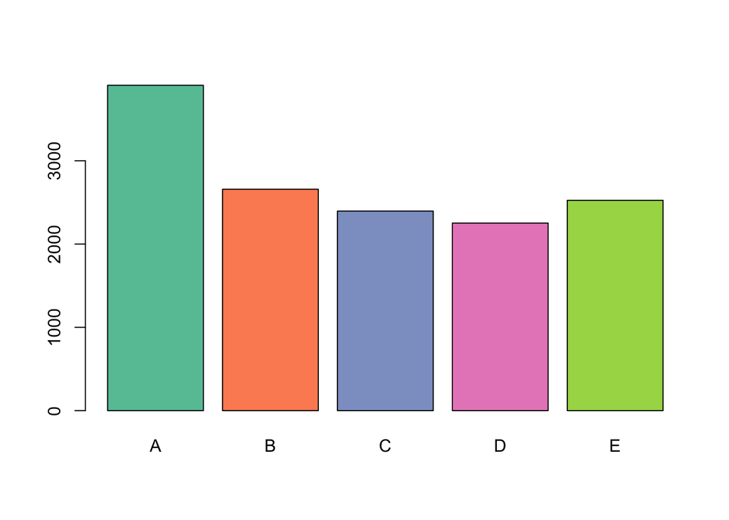

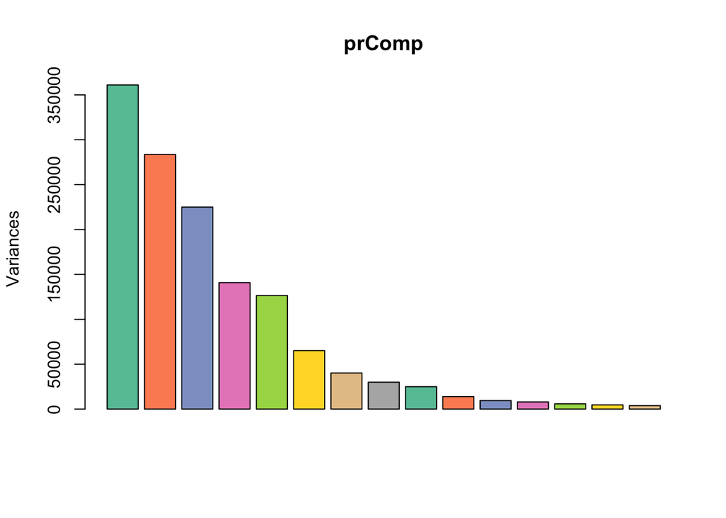

Next, model were fit using k-nearest neighbors, random forests, Naive Bayes, linear discriminant analysis, and support vector machine. The accuracy of the model on the testing data was examined, showing that the KNN, Random Forset and SVM models had far superior accuracy.

```
## [1] "Testing: K-Nearest Neighbor(k=3):  95.66"
```

```
##        yTest
## testKNN    A    B    C    D    E
##       A 1141   20   12    8    2
##       B    9  745    8    1    9
##       C   11   29  682   27    5
##       D    9    3   16  638    5
##       E    2    1    1    1  737
```

```
## [1] "Testing: Random Forest:  95.51"
```

```
##       yTest
## testRF    A    B    C    D    E
##      A 1148   20   10   10    1
##      B    7  743   12    1    6
##      C   13   24  680   33    8
##      D    3    7   13  628    5
##      E    1    4    4    3  738
```

```
## [1] "Testing: Naive Bayes:  46.97"
```

```
##       yTest
## testNB   A   B   C   D   E
##      A 783 172 301  98 110
##      B  76 352  38  71 217
##      C 148  70 228 104 104
##      D 102  92  53 347 101
##      E  63 112  99  55 226
```

```
## [1] "Testing: LDA:  42.12"
```

```
##        yTest
## testLDA   A   B   C   D   E
##       A 783 229 305  77 159
##       B  74 273  86 107 187
##       C 103  75 175  81 124
##       D 142 109  52 322 105
##       E  70 112 101  88 183
```

```
## [1] "Testing: SVM:  97.84"
```

```
##        yTest
## testSVM    A    B    C    D    E
##       A 1156    9    4    1    1
##       B    8  768    5    0    3
##       C    3   14  700   13    0
##       D    2    1   10  655    0
##       E    3    6    0    6  754
```

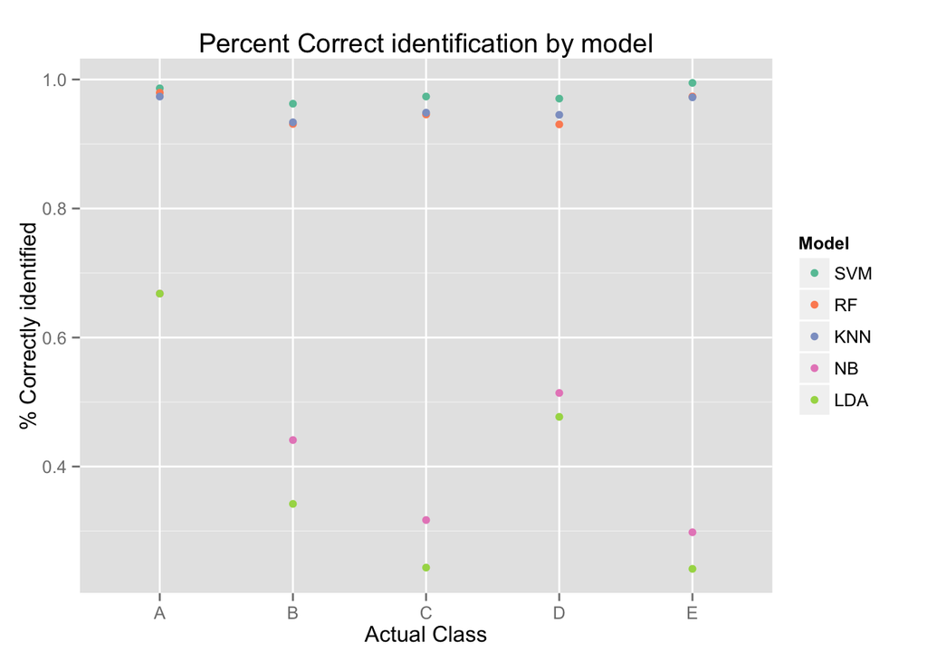

Based on this analysis, the SVM, K-nearest neighbor and the Random Forest models showed to be the best fits. Next, an average model, combine these three with a majority votes approach was found. However, based on the testing data, the SVM model was superior to that of the average model.

```
## [1] "Performance of average model:  97.02"
```

```
##    yTest
## t      A    B    C    D    E
##   A 1155   14   11    4    2
##   B    5  761    7    0    4
##   C    8   17  689   23    4
##   D    3    3   11  646    0
##   E    1    3    1    2  748
```

```
## [1] "Performance of RF model:  96"
```

```
## [1] "Performance of KNN model:  96"
```

```
## [1] "Performance of SVM model:  98"
```

In order to assess the out of sample accuracy of the SVM model, it was applied to the Cross Validation data set. This showed that the model had a correct prediction rate of 98%. The model was also used on 20 test cases and was able to accurately predict all 20.

```
##      yCV
## cvSVM   A   B   C   D   E
##     A 491   3   2   0   1
##     B   3 331   2   0   1
##     C   4   6 297   5   0
##     D   2   1   5 281   0
##     E   2   0   1   3 322
```

```
## [1] "Performance of out of sample SVM model:  98"
```

Read more: http://groupware.les.inf.puc-rio.br/har#ixzz38h490KfI

[^1]: Velloso, E.; Bulling, A.; Gellersen, H.; Ugulino, W.; Fuks, H. Qualitative Activity Recognition of Weight Lifting Exercises. Proceedings of 4th International Conference in Cooperation with SIGCHI (Augmented Human ’13) . Stuttgart, Germany: ACM SIGCHI, 2013.